# Selina Narain DTSC 630 Homework 2

2023-02-24

## 0.1 Question 1

**The dataframe rainforest from DAAG package has data on several rainforest species.**

**Explore the dataframe rainforest using str, summary, table functions.**

```r
library(DAAG)
data("rainforest")
str(rainforest)
```

```
## 'data.frame':    65 obs. of  7 variables:
##  $ dbh    : num  6 23 20 23 24 5 5 8 10 8 ...
##  $ wood   : num  NA 353 208 445 590 14 10 31 59 30 ...
##  $ bark   : num  NA NA NA NA NA NA NA NA NA NA ...
##  $ root   : num  6 135 NA NA NA 2 NA NA NA 6 ...
##  $ rootsk : num  0.3 13 NA NA NA 2.4 NA NA NA 1 ...
##  $ branch : num  NA 35 41 50 NA NA NA NA NA 4 ...
##  $ species: Factor w/ 4 levels "Acacia mabellae",..: 1 1 1 1 1 1 1 1 1 1 ...
```

```r
summary(rainforest)
```

```
##       dbh             wood             bark             root
##  Min.   : 4.00   Min.   :   3.0   Min.   :  8.00   Min.   :  2.00
##  1st Qu.: 8.00   1st Qu.:  29.0   1st Qu.: 11.75   1st Qu.:  6.00
##  Median :12.00   Median : 100.0   Median : 45.50   Median : 16.00
##  Mean   :16.06   Mean   : 265.4   Mean   : 51.00   Mean   : 30.85
##  3rd Qu.:22.00   3rd Qu.: 386.5   3rd Qu.: 84.75   3rd Qu.: 44.00
##  Max.   :56.00   Max.   :1530.0   Max.   :105.00   Max.   :135.00
##                  NA's   :1        NA's   :61       NA's   :52
##      rootsk           branch                  species
##  Min.   : 0.300   Min.   :  4.00   Acacia mabellae:16
##  1st Qu.: 1.300   1st Qu.:  9.00   C. fraseri     :12
##  Median : 2.400   Median : 25.00   Acmena smithii :26
##  Mean   : 7.477   Mean   : 32.86   B. myrtifolia  :11
##  3rd Qu.:13.000   3rd Qu.: 45.50
##  Max.   :24.000   Max.   :120.00
##  NA's   :52       NA's   :22
```

```r
#table(rainforest)
```

**From the above exploration, what are the names and numbers of the species in the data set?**

The names and numbers of the species in the data set are: Acacia mabellae: 16 C. fraseri: 12  
Acmena smithii: 26 B. myrtifolia: 11

**Plot two side-by-side graphs:**  
the left of which is  
– a histogram showing the distribution of the variable dbh (diameter at base height) for all the trees;  
– superimposed with a density plot (which estimates the number of values per unit interval) using density() function.

The graph on the right is a similar histogram with fitted density curve for trees of species “Acmena smithii”.

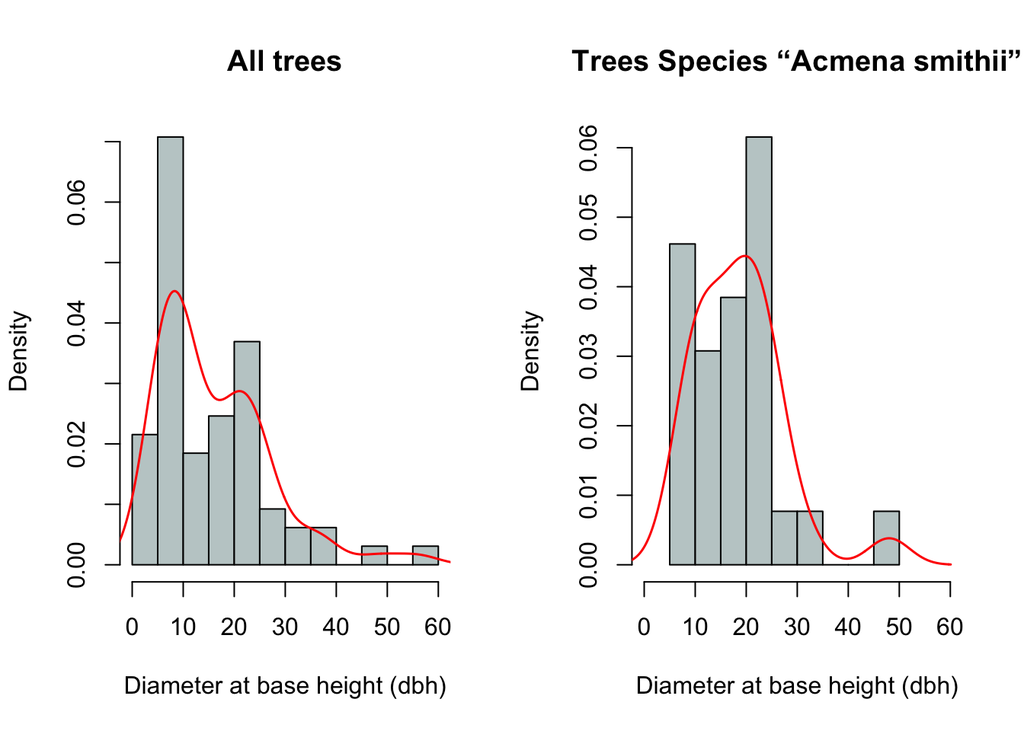

```r
#Setting the plot area to a 1 by 2 array. One row of plots, and two columns.
par(mfrow = c(1,2))

#Left graph
hist(rainforest$dbh,
     main="All trees",
     freq = FALSE,
     xlab = "Diameter at base height (dbh)",
     col = "azure3",
     prob = TRUE,
     border = "black")
#Density plot
lines(density(rainforest$dbh), col = 'red', lwd = 1.5)

#Takes subset of Acmena smithii species data and load into dataframe
df_acmena <- subset(rainforest, species=="Acmena smithii")

#Right graph
hist(df_acmena$dbh,
     main="Trees Species “Acmena smithii”",
     xlab = "Diameter at base height (dbh)",
     xlim = c(0, 60),
     col = "azure3",
     prob = TRUE,
     border = "black")

#Density plot
lines(density(df_acmena$dbh), col = 'red', lwd = 1.5)
```

## 0.2 Question 2

**Use the mtcars dataset, provided by base R to plot 3 scatter plots in the same graph.** **The three pair of data are (mpg, drat), (mpg, wt), (mpg, qsec).** **You can start with the main plot using plot function (mpg, drat, …), then add/superimpose the other two plots by points() as follows:**  
*plot(mpg, drat, …)*  
*points(mpg, wt, …)*  
*points(mpg, qsec, …)*

```r
data(mtcars)
head(mtcars)
```

```
##                    mpg cyl disp  hp drat    wt  qsec vs am gear carb
## Mazda RX4         21.0   6  160 110 3.90 2.620 16.46  0  1    4    4
## Mazda RX4 Wag     21.0   6  160 110 3.90 2.875 17.02  0  1    4    4
## Datsun 710        22.8   4  108  93 3.85 2.320 18.61  1  1    4    1
## Hornet 4 Drive    21.4   6  258 110 3.08 3.215 19.44  1  0    3    1
## Hornet Sportabout 18.7   8  360 175 3.15 3.440 17.02  0  0    3    2
## Valiant           18.1   6  225 105 2.76 3.460 20.22  1  0    3    1
```

```r
str(mtcars)
```

```
## 'data.frame':    32 obs. of  11 variables:
##  $ mpg : num  21 21 22.8 21.4 18.7 18.1 14.3 24.4 22.8 19.2 ...
##  $ cyl : num  6 6 4 6 8 6 8 4 4 6 ...
##  $ disp: num  160 160 108 258 360 ...
##  $ hp  : num  110 110 93 110 175 105 245 62 95 123 ...
##  $ drat: num  3.9 3.9 3.85 3.08 3.15 2.76 3.21 3.69 3.92 3.92 ...
##  $ wt  : num  2.62 2.88 2.32 3.21 3.44 ...
##  $ qsec: num  16.5 17 18.6 19.4 17 ...
##  $ vs  : num  0 0 1 1 0 1 0 1 1 1 ...
##  $ am  : num  1 1 1 0 0 0 0 0 0 0 ...
##  $ gear: num  4 4 4 3 3 3 3 4 4 4 ...
##  $ carb: num  4 4 1 1 2 1 4 2 2 4 ...
```

```r
summary(mtcars)
```

```
##       mpg             cyl             disp             hp
##  Min.   :10.40   Min.   :4.000   Min.   : 71.1   Min.   : 52.0
##  1st Qu.:15.43   1st Qu.:4.000   1st Qu.:120.8   1st Qu.: 96.5
##  Median :19.20   Median :6.000   Median :196.3   Median :123.0
##  Mean   :20.09   Mean   :6.188   Mean   :230.7   Mean   :146.7
##  3rd Qu.:22.80   3rd Qu.:8.000   3rd Qu.:326.0   3rd Qu.:180.0
##  Max.   :33.90   Max.   :8.000   Max.   :472.0   Max.   :335.0
##       drat             wt             qsec             vs
##  Min.   :2.760   Min.   :1.513   Min.   :14.50   Min.   :0.0000
##  1st Qu.:3.080   1st Qu.:2.581   1st Qu.:16.89   1st Qu.:0.0000
##  Median :3.695   Median :3.325   Median :17.71   Median :0.0000
##  Mean   :3.597   Mean   :3.217   Mean   :17.85   Mean   :0.4375
##  3rd Qu.:3.920   3rd Qu.:3.610   3rd Qu.:18.90   3rd Qu.:1.0000
##  Max.   :4.930   Max.   :5.424   Max.   :22.90   Max.   :1.0000
##        am              gear            carb
##  Min.   :0.0000   Min.   :3.000   Min.   :1.000
##  1st Qu.:0.0000   1st Qu.:3.000   1st Qu.:2.000
##  Median :0.0000   Median :4.000   Median :2.000
##  Mean   :0.4062   Mean   :3.688   Mean   :2.812
##  3rd Qu.:1.0000   3rd Qu.:4.000   3rd Qu.:4.000
##  Max.   :1.0000   Max.   :5.000   Max.   :8.000
```

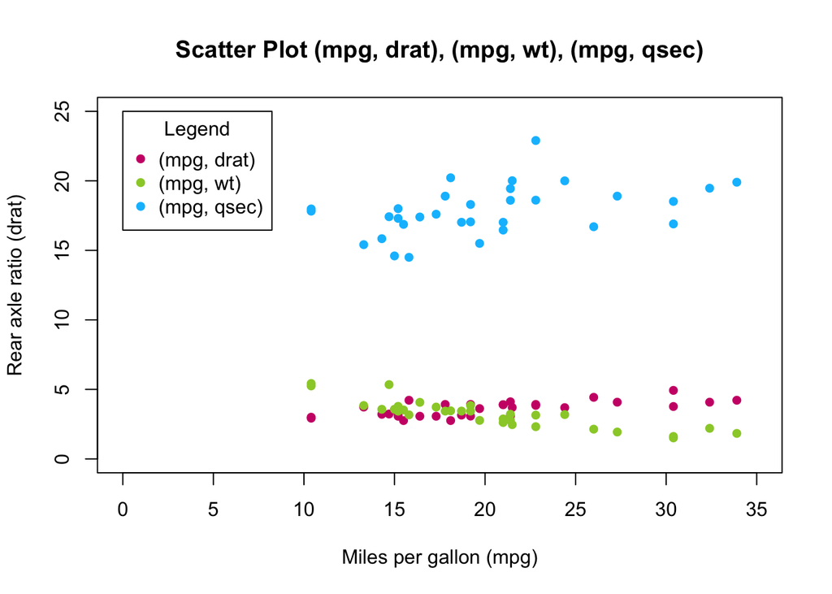

```r
#plot(mtcars$drat)
#plot(mtcars$wt)
#plot(mtcars$qsec)

#Main plot using plot function (mpg, drat)
plot(mtcars$mpg,
     mtcars$drat,
     main = "Scatter Plot (mpg, drat), (mpg, wt), (mpg, qsec)",
     xlab = "Miles per gallon (mpg)",
     ylab = "Rear axle ratio (drat)",
     xlim = c(0, 35),
     ylim = c(0, 25),
     pch = 16,
     col = "deeppink3")
#Add/superimpose the other two plots by points() for (mpg, wt), (mpg, qsec)
points(mtcars$mpg,
       mtcars$wt,
       pch = 16,
       col = "yellowgreen")
points(mtcars$mpg,
       mtcars$qsec,
       pch = 16,
       col = "deepskyblue")

#Creating legend (colors, symbols, labels)
leg_cols <- c("deeppink3", "yellowgreen", "deepskyblue")
leg_sym <- c(16, 16, 16)
leg_lab <- c("(mpg, drat)", "(mpg, wt)", "(mpg, qsec)")

legend(x = 0, y = 25, col = leg_cols, pch = leg_sym, legend = leg_lab, title = "Legend")
```